# R for Loss Data Analytics

### 4.4.3 Nonparametric Estimation Tools For Model Selection

#### 4.4.3.1 Fit Distributions To The Claims Data

The results below fits gamma and Pareto distribution to the claims data.

```r
library(MASS)
library(VGAM)
# Inference assuming a gamma distribution
fit.gamma2 <- glm(Claim~1, data=ClaimData,family=Gamma(link=log))
summary(fit.gamma2, dispersion = gamma.dispersion(fit.gamma2))
```

```
Call:
glm(formula = Claim ~ 1, family = Gamma(link = log), data = ClaimData)

Deviance Residuals:
   Min      1Q  Median      3Q     Max
-4.287  -2.258  -1.764  -1.178  30.926

Coefficients:
            Estimate Std. Error z value Pr(>|z|)
(Intercept) 10.18952    0.04999   203.8   <2e-16 ***
---
Signif. codes:  0 '***' 0.001 '**' 0.01 '*' 0.05 '.' 0.1 ' ' 1

(Dispersion parameter for Gamma family taken to be 3.441204)

    Null deviance: 6569.1  on 1376  degrees of freedom
Residual deviance: 6569.1  on 1376  degrees of freedom
AIC: 28414

Number of Fisher Scoring iterations: 14
```

```r
(theta<-exp(coef(fit.gamma2))*gamma.dispersion(fit.gamma2)) #mu=theta/alpha
```

```
(Intercept)
   91613.78
```

```r
(alpha<-1/gamma.dispersion(fit.gamma2) )
```

```
[1] 0.2905959
```

```r
#  Inference assuming a Pareto Distribution
fit.pareto <- vglm(Claim ~ 1, paretoII, loc=0, data = ClaimData)
summary(fit.pareto)
```

```
Call:
vglm(formula = Claim ~ 1, family = paretoII, data = ClaimData,
    loc = 0)


Pearson residuals:
                Min      1Q Median     3Q   Max
loge(scale)  -6.332 -0.8289 0.1875 0.8832 1.174
loge(shape) -10.638  0.0946 0.4047 0.4842 0.513

Coefficients:
                Estimate Std. Error z value Pr(>|z|)
(Intercept):1  7.7329210  0.0933332  82.853   <2e-16 ***
(Intercept):2 -0.0008753  0.0538642  -0.016    0.987
---
Signif. codes:  0 '***' 0.001 '**' 0.01 '*' 0.05 '.' 0.1 ' ' 1

Number of linear predictors:  2

Names of linear predictors: loge(scale), loge(shape)

Log-likelihood: -13404.64 on 2752 degrees of freedom

Number of iterations: 5

No Hauck-Donner effect found in any of the estimates
```

```r
head(fitted(fit.pareto))
```

```
        [,1]
[1,] 2285.03
[2,] 2285.03
[3,] 2285.03
[4,] 2285.03
[5,] 2285.03
[6,] 2285.03
```

```r
exp(coef(fit.pareto))
```

```
(Intercept):1 (Intercept):2
 2282.2590626     0.9991251
```

#### 4.4.3.2 Graphical Comparison of Distributions

The graphs below reinforces the technique of overlaying graphs for comparison purposes using both the distribution function and density function. Pareto distribution provides a better fit.

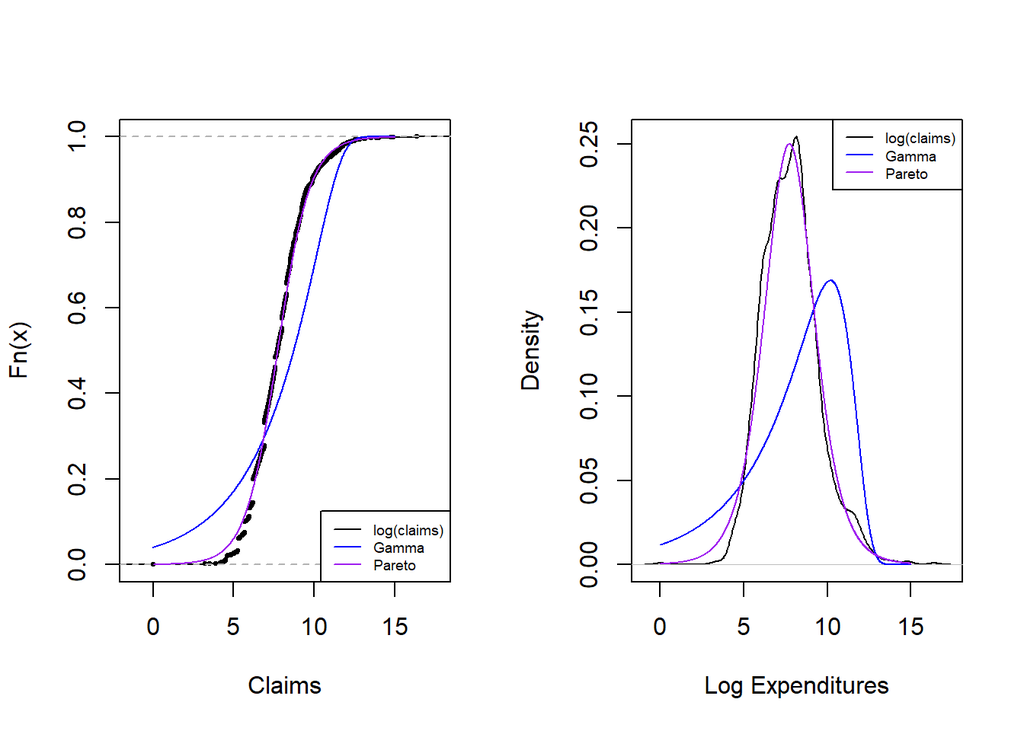

```r
# Plotting the fit using densities (on a logarithmic scale)
# None of these distributions is doing a great job....
x <- seq(0,15,by=0.01)

par(mfrow=c(1, 2))
LogPercentiles  <- ecdf(log(ClaimData$Claim))
plot(LogPercentiles,  main="", xlab="Claims", cex=0.4)
Fgamma_ex = pgamma(exp(x), shape = alpha, scale=theta)
lines(x,Fgamma_ex,col="blue")
Fpareto_ex = pparetoII(exp(x),loc=0,shape = exp(coef(fit.pareto)[2]), scale = exp(coef(fit.pareto)[1]))
lines(x,Fpareto_ex,col="purple")
legend("bottomright", c("log(claims)", "Gamma","Pareto"), lty=1, cex=0.6,col = c("black","blue","purple"))

plot(density(log(ClaimData$Claim)) ,main="", xlab="Log Expenditures")
fgamma_ex = dgamma(exp(x), shape = alpha, scale=theta)*exp(x)
lines(x,fgamma_ex,col="blue")
fpareto_ex = dparetoII(exp(x),loc=0,shape = exp(coef(fit.pareto)[2]), scale = exp(coef(fit.pareto)[1]))*exp(x)
lines(x,fpareto_ex,col="purple")
legend("topright", c("log(claims)", "Gamma","Pareto"), lty=1, cex=0.6,col = c("black","blue","purple"))
```

#### 4.4.3.3 P-P Plots

Shows $pp$ plots for the Property Fund data; the fitted gamma is on the left and the fitted Pareto is on the right. Pareto distribution provides a better fit again.

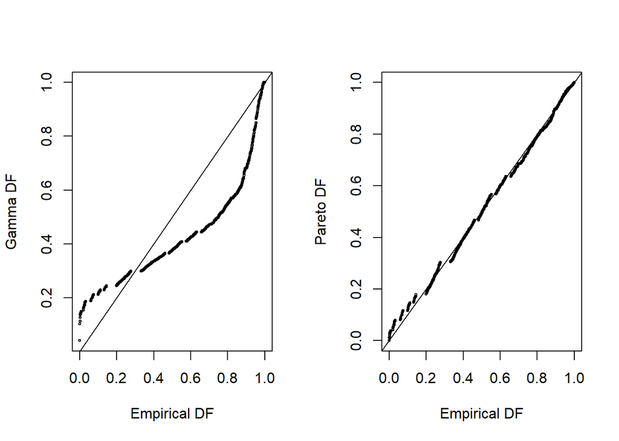

```r
#  PP Plot
par(mfrow=c(1, 2))
Fgamma_ex = pgamma(ClaimData$Claim, shape = alpha, scale=theta)
plot(Percentiles(ClaimData$Claim),Fgamma_ex, xlab="Empirical DF", ylab="Gamma DF",cex=0.4)
abline(0,1)
Fpareto_ex = pparetoII(ClaimData$Claim,loc=0,shape = exp(coef(fit.pareto)[2]), scale = exp(coef(fit.pareto)[1]))
plot(Percentiles(ClaimData$Claim),Fpareto_ex, xlab="Empirical DF", ylab="Pareto DF",cex=0.4)
abline(0,1)
```

```r
#dev.off()
```

#### 4.4.3.4 Q-Q Plots

In the graphs below the quantiles are plotted on the original scale in the left-hand panels, on the log scale in the right-hand panel, to allow the analyst to see where a fitted distribution is deficient.

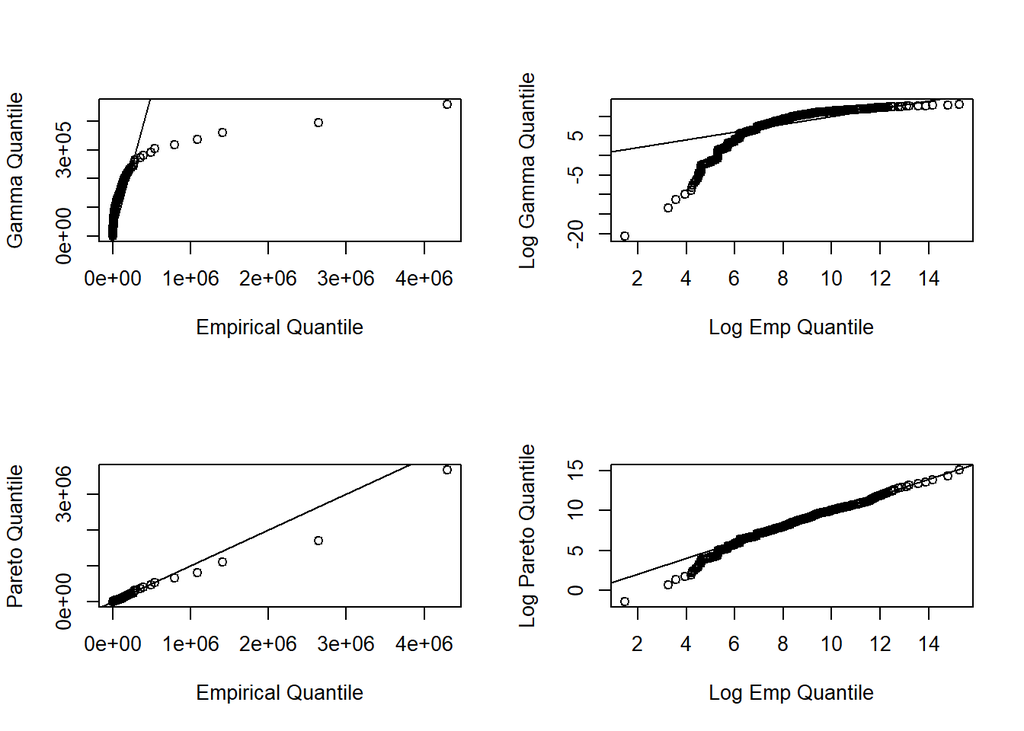

```r
##q-q plot
par(mfrow=c(2, 2))
xseq = seq(0.0001, 0.9999, by=1/length(ClaimData$Claim))
empquant = quantile(ClaimData$Claim, xseq)
Gammaquant = qgamma(xseq, shape = alpha, scale=theta)
plot(empquant, Gammaquant, xlab="Empirical Quantile", ylab="Gamma Quantile")
abline(0,1)
plot(log(empquant), log(Gammaquant), xlab="Log Emp Quantile", ylab="Log Gamma Quantile")
abline(0,1)
Paretoquant = qparetoII(xseq,loc=0,shape = exp(coef(fit.pareto)[2]), scale = exp(coef(fit.pareto)[1]))
plot(empquant, Paretoquant, xlab="Empirical Quantile", ylab="Pareto Quantile")
abline(0,1)
plot(log(empquant), log(Paretoquant), xlab="Log Emp Quantile", ylab="Log Pareto Quantile")
abline(0,1)
```

#### 4.4.3.5 Goodness of Fit Statistics

For reporting results, it can be effective to supplement graphical displays with selected statistics that summarize model goodness of fit. The results below provides three commonly used goodness of fit statistics.

```r
library(goftest )
#Kolmogorov-Smirnov # the test statistic is "D"
ks.test(ClaimData$Claim, "pgamma", shape = alpha, scale=theta)
```

```
    One-sample Kolmogorov-Smirnov test

data:  ClaimData$Claim
D = 0.26387, p-value < 2.2e-16
alternative hypothesis: two-sided
```

```r
ks.test(ClaimData$Claim, "pparetoII",loc=0,shape = exp(coef(fit.pareto)[2]), scale = exp(coef(fit.pareto)[1]))
```

```
    One-sample Kolmogorov-Smirnov test

data:  ClaimData$Claim
D = 0.047824, p-value = 0.003677
alternative hypothesis: two-sided
```

```r
#Cramer-von Mises # the test statistic is "omega2"
cvm.test(ClaimData$Claim, "pgamma", shape = alpha, scale=theta)
```

```
    Cramer-von Mises test of goodness-of-fit
    Null hypothesis: Gamma distribution
    with parameters shape = 0.290595934110839, scale =
    91613.779421033

data:  ClaimData$Claim
omega2 = 33.378, p-value = 2.549e-05
```

```r
cvm.test(ClaimData$Claim, "pparetoII",loc=0,shape = exp(coef(fit.pareto)[2]), scale = exp(coef(fit.pareto)[1]))
```

```
    Cramer-von Mises test of goodness-of-fit
    Null hypothesis: distribution 'pparetoII'
    with parameters shape = 0.999125131378519, scale =
    2282.25906257586

data:  ClaimData$Claim
omega2 = 0.38437, p-value = 0.07947
```

```r
#Anderson-Darling # the test statistic is "An"
ad.test(ClaimData$Claim, "pgamma", shape = alpha, scale=theta)
```

```
    Anderson-Darling test of goodness-of-fit
    Null hypothesis: Gamma distribution
    with parameters shape = 0.290595934110839, scale =
    91613.779421033

data:  ClaimData$Claim
An = Inf, p-value = 4.357e-07
```

```r
ad.test(ClaimData$Claim, "pparetoII",loc=0,shape = exp(coef(fit.pareto)[2]), scale = exp(coef(fit.pareto)[1]))
```

```
    Anderson-Darling test of goodness-of-fit
    Null hypothesis: distribution 'pparetoII'
    with parameters shape = 0.999125131378519, scale =
    2282.25906257586

data:  ClaimData$Claim
An = 4.1264, p-value = 0.007567
```

## 4.5 MLE for Grouped Data

### 4.5.1 MLE for Grouped Data- SOA Exam C # 276

Losses follow the distribution function $F(x)=1-(\theta/x),\quad x>0$. A sample of 20 losses resulted in the following:

| Interval | Number of Losses |
| --- | --- |
| (0,10] | 9 |
| (10,25] | 6 |
| (25,infinity) | 5 |

Calculate the maximum likelihood estimate of $\theta$.

```r
##Log Likelihood function
likgrp <- function(theta) {
  loglike <-log(((1-(theta/10))^9)*(((theta/10)-(theta/25))^6)* (((theta/25))^5))
  return(-sum(loglike))
}
#  "optim" is a general purpose minimization function
grplik <- optim(c(1),likgrp,method=c("L-BFGS-B"),hessian=TRUE)
#Estimates - Answer "B" on SoA Problem
grplik$par
```

```
[1] 5.5
```

```r
#standard error
sqrt(diag(solve(grplik$hessian)))
```

```
[1] 1.11243
```

```r
#t-statistics
(tstat = grplik$par/sqrt(diag(solve(grplik$hessian))) )
```

```
[1] 4.944132
```

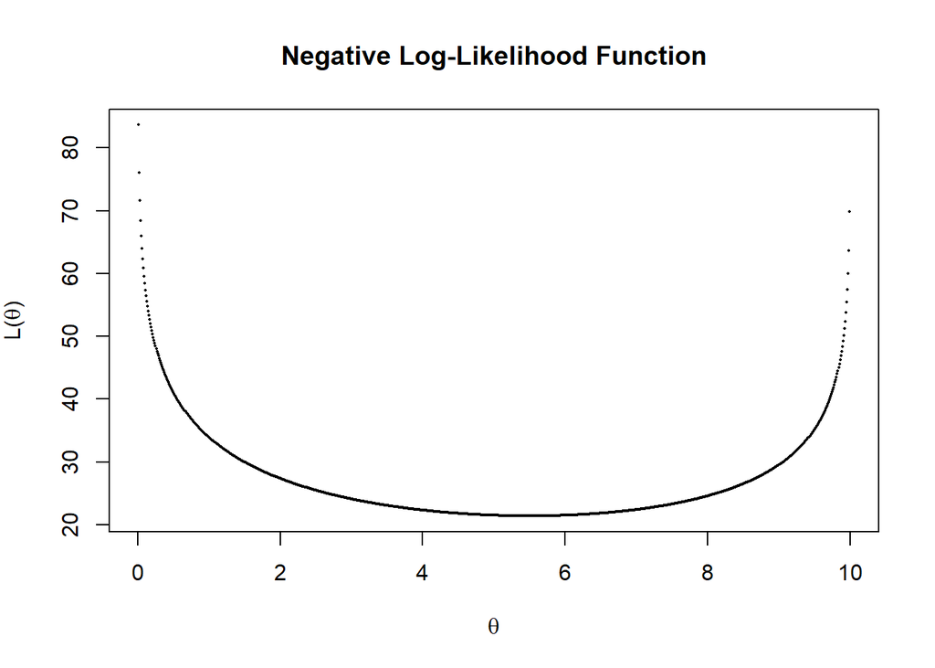

```r
#Plot of Negative Log-Likelihood function
vllh = Vectorize(likgrp,"theta")
theta=seq(0,10, by=0.01)
plot(theta, vllh(theta), pch=16, main ="Negative Log-Likelihood Function" , cex=.25,
     xlab=expression(theta), ylab=expression(paste("L(",theta,")")))
```

# 5 Simulation

*This file contains illustrative **R** code for computing important count distributions. When reviewing this code, you should open an **R** session, copy-and-paste the code, and see it perform. Then, you will be able to change parameters, look up commands, and so forth, as you go.*

## 5.1 Simulation - Inversion Method

This section shows how to use the inversion method to simulate claims from a gamma distribution. The results below are summary statistics from the simulated data.

```r
##Simulation-gamma
library(moments)
set.seed(2) #set seed to reproduce work
nTot<-20000  #number of simulations
alpha<-2
theta<-100

Losses<-rgamma(nTot,alpha,scale = theta)
summary(Losses)
```

```
     Min.   1st Qu.    Median      Mean   3rd Qu.      Max.
   0.0921   96.3265  167.8035  200.1747  268.2257 1110.1298
```

```r
k<-0.95
PercentileLoss<-quantile(Losses,k)     # Kth percentile of Losses
PercentileLoss
```

```
     95%
473.8218
```

```r
#######################################
#OR you can use this method to simulate losses
#Fx<-runif(nTot)
#Losses<-qgamma(Fx,alpha,scale=theta)
#######################################
# For the Pareto Distribution, use
#library(VGAM)
# nTot<-10000  #number of simulations
# alpha<-3
# theta<-25000
# Losses<-rparetoII(nTot,scale=theta,shape=alpha)
# rparetoII(nTot,scale=theta,shape=alpha)
```

A few quick notes on these commands:

- The `rgamma()` function randomly generates data from the Gamma distribution. In this illustration the data was generated from a gamma distribution with parameters `shape=alpha=2` and `scale=theta=100`.
- The `quantile()` function provides sample quantiles corresponding to the given probabilities. Here we wanted the simulated loss data corresponding to the 95th percentile.

## 5.2 Comparing Moments from The Simulated Data to Theoretical Moments

```r
library(pander)
###Raw moments for k=0.5
# Theoretical
k<-0.5
T0.5<-round(((theta^k)*gamma(alpha+k))/gamma(alpha),2)

#Simulated data raw moments
S0.5<-round(moment(Losses, order = k, central = FALSE),2)


###Raw moments for k=1
# Theoretical
k<-1
T1<-((theta^k)*gamma(alpha+k))/gamma(alpha)

#Simulated data raw moments
S1<-round(moment(Losses, order = k, central = FALSE),2)

###Raw moments for k=2
# Theoretical
k<-2
T2<-((theta^k)*gamma(alpha+k))/gamma(alpha)

#Simulated data raw moments
S2<-round(moment(Losses, order = k, central = FALSE),2)

###Raw moments for k=3
# Theoretical
k<-3
T3<-((theta^k)*gamma(alpha+k))/gamma(alpha)

#Simulated data raw moments
S3<-round(moment(Losses, order = k, central = FALSE),2)

###Raw moments for k=3
# Theoretical
k<-4
T4<-((theta^k)*gamma(alpha+k))/gamma(alpha)

#Simulated data raw moments
S4<-round(moment(Losses, order = k, central = FALSE),2)

pander(rbind(c("k",0.5,1,2,3,4),c("Theoretical",T0.5,T1,T2,T3,T4),c("Simulated",S0.5,S1,S2,S3,S4)))
```

| k | 0.5 | 1 | 2 | 3 | 4 |
| --- | --- | --- | --- | --- | --- |
| Theoretical | 13.29 | 200 | 60000 | 2.4e+07 | 1.2e+10 |
| Simulated | 13.3 | 200.17 | 60069.73 | 23993892.53 | 11897735665.89 |

A few quick notes on these commands:

- The `moment()` function computes all the sample moments of the chosen type up to a given order. In this illustration, we wanted the raw sample moments of the *kth* order.
- The `round()` function was used to round values.

# 6 Aggregate Claim Simulation

*This file demonstrates simulation of aggregate claim distributions. When reviewing this code, you should open an **R** session, copy-and-paste the code, and see it perform. Then, you will be able to change parameters, look up commands, and so forth, as you go.*

## 6.1 Collective Risk Model: without coverage modifications

S = X_1 + … + X_N

Assume N ~ Poisson(lambda=2) and X ~ Pareto(alpha=3,theta=5000)

### 6.1.1 Set Parameters

```r
lambda <- 2
alpha <- 3
theta <- 5000
```

### 6.1.2 Show frequency and severity distributions

Graphing the our frequency (N) and severity (X) distributions

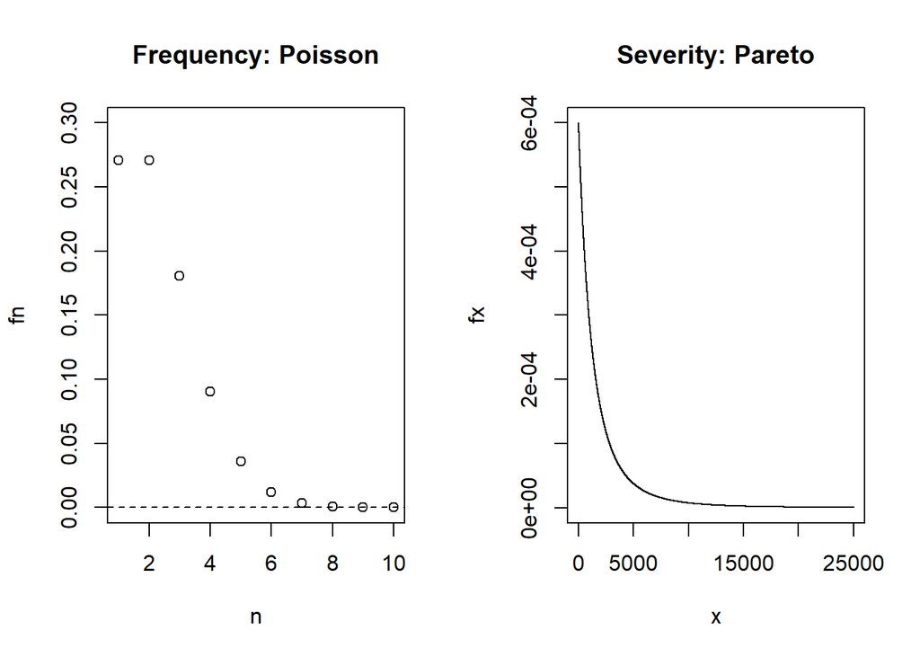

```r
par(mfrow=c(1,2))

n <- 1:10
fn <- dpois(1:10,lambda)

plot(n,fn,ylim=c(0,0.3),main="Frequency: Poisson")
abline(h=0,lty=2)

x <- seq(1,25000,1)
fx <- alpha*theta^alpha/(x+theta)^(alpha+1)

plot(x,fx,type="l",main="Severity: Pareto")
```

### 6.1.3 Set sample size for the simulation

We’re going to simulate 5000 observations of S

```r
set.seed(123)
size <- 5000
S <- rep(NA,size)
N <- rpois(size,lambda)
for (i in 1:size){
  uu <- runif(N[i])
  X <- theta*((1-uu)^(-1/alpha)-1)
  S[i] <- sum(X)
}
```

### 6.1.4 Show distribution of aggregate loss S

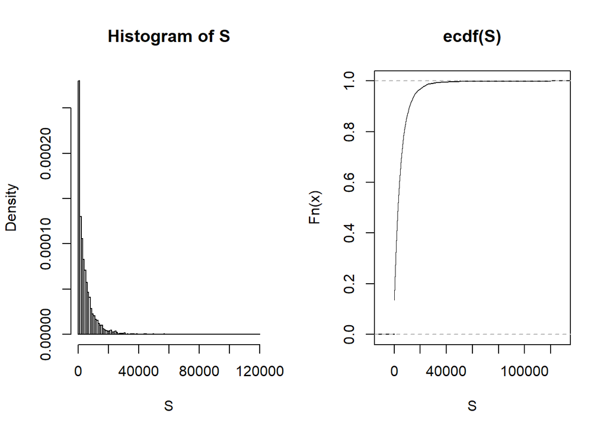

```r
par(mfrow=c(1,2))
hist(S,freq=F,breaks=100)
plot(ecdf(S),xlab="S")
```

## 6.2 Applications

### 6.2.1 Find descriptive statistics

Here we show numerical descriptions of our simulated distribution S

```r
mean(S)                             # sample mean
```

```
[1] 4829.894
```

```r
sd(S)                               # sample standard deviation
```

```
[1] 6585.567
```

```r
quantile(S,prob=c(0.05,0.5,0.95))   # percentiles
```

```
       5%       50%       95%
    0.000  2846.073 15983.408
```

### 6.2.2 Calculate cdf

```r
sum((S==0))/size
```

```
[1] 0.1348
```

Pr(S=0)

```r
sum(S<=mean(S))/size
```

```
[1] 0.6578
```

Pr(S<=E(S))

```r
sum(S>mean(S))/size
```

```
[1] 0.3422
```

Pr(S>E(S))

### 6.2.3 Calculate risk measures

CTE is also known as TVaR

```r
VaR <- quantile(S,prob=0.99)         # significance level = 0.01
CTE <- sum(S*(S>VaR))/sum((S>VaR))
rm <- c(VaR,CTE)
names(rm) <- c("VaR","CTE")
print(rm)
```

```
     VaR      CTE
28636.56 43193.19
```

### 6.2.4 Pricing stop-loss insurance - Set deductible

Here we plot how the premium for a stop-loss insurance product changes based on the size of the deductible

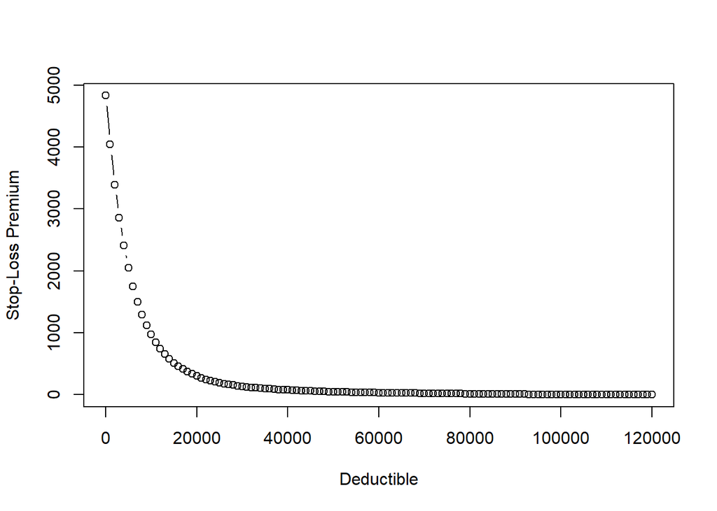

```r
par(mfrow=c(1,1))
d <- seq(0,120000,1000)
price <- rep(NA,length(d))
for (i in 1:length(d)){
  price[i] = sum((S-d[i])*(S>d[i]))/size
}
plot(d,price,xlab="Deductible",ylab="Stop-Loss Premium",type="b")
```

# 7 FreqSev

*This file contains illustrative **R** code for calculations involving frequency and severity of distributions. When reviewing this code, you should open an **R** session, copy-and-paste the code, and see it perform. Then, you will be able to change parameters, look up commands, and so forth, as you go.*

## 7.1 Getting the Data

Before we can do any analysis we must import the data.

### 7.1.1 read data “MassAuto.csv”

Import the excel file into R.

```r
dat <- read.csv(file = "Data/MassAuto.csv",header=TRUE)
```

### 7.1.2 Check Variable Names

This code outputs a list of all the variable names of the excel file. This is useful for determining what kind of data you re working with.

```r
names(dat)
```

```
[1] "VIN"       "Territory" "Class"     "Loss1"     "Loss2"
```

### 7.1.3 Calculate Total Losses in “dat”

This code creates a new column representing the sum of the two loss columns.

```r
dat$Loss <- dat$Loss1 + dat$Loss2
```

## 7.2 Fit Frequency Models

### 7.2.1 Prepare Data for Frequency Models

You may have to install the package “dplyr” to run this code.

```r
library(dplyr)
freq.dat <- dat %>% group_by(VIN) %>% summarise(tLoss = sum(Loss),count = sum(Loss>0))
dim(freq.dat)
```

```
[1] 49894     3
```

### 7.2.2 Fit Poisson distribution

Here we fit a poisson distrubtion to the data and run log likelihood to determine the most likely parameter for the distribution. We then calculate the standard error of this estimate.

#### 7.2.2.1 Define the pmf for the Poisson Distribution

```r
loglikPois<-function(parms){
  lambda=parms[1]
  llk <- -sum(log(dpois(freq.dat$count,lambda)))
  llk
}
ini.Pois <- 1
zop.Pois <- nlminb(ini.Pois,loglikPois,lower=c(1e-6),upper=c(Inf))
print(zop.Pois)
```

```
$par
[1] 0.04475488

$objective
[1] 9243.476

$convergence
[1] 0

$iterations
[1] 17

$evaluations
function gradient
      24       20

$message
[1] "relative convergence (4)"
```

#### 7.2.2.2 Obtain Standard Error

```r
library(numDeriv)
est <- zop.Pois$par
names(est) <- c("lambda")
hess<-hessian(loglikPois,est)
se <-sqrt(diag(solve(hess)))
print(cbind(est,se))
```

```
              est           se
lambda 0.04475488 0.0009471004
```

### 7.2.3 Fit Negative Binomial Distribution

Now we fit a negative binomial distribution to the data using log likelihood.

We then calculate the standard error of this estimate.

#### 7.2.3.1 Define pmf for Negative Binomial

```r
dnb <- function(y,r,beta){
  gamma(y+r)/gamma(r)/gamma(y+1)*(1/(1+beta))^r*(beta/(1+beta))^y
}
loglikNB<-function(parms){
  r=parms[1]
  beta=parms[2]
  llk <- -sum(log(dnb(freq.dat$count,r,beta)))
  llk
}
ini.NB <- c(1,1)
zop.NB <- nlminb(ini.NB,loglikNB,lower=c(1e-6,1e-6),upper=c(Inf,Inf))
print(zop.NB)
```

```
$par
[1] 0.86573901 0.05169541

$objective
[1] 9218.902

$convergence
[1] 0

$iterations
[1] 27

$evaluations
function gradient
      32       63

$message
[1] "relative convergence (4)"
```

#### 7.2.3.2 Obtain Standard Error

```r
library(numDeriv)
est <- zop.NB$par
names(est) <- c("r","beta")
hess<-hessian(loglikNB,est)
se <-sqrt(diag(solve(hess)))
print(cbind(est,se))
```

```
            est          se
r    0.86573901 0.161126426
beta 0.05169541 0.009686412
```

### 7.2.4 Goodness-of-Fit

Here we calculate goodness of fit for the emipircal, poission, and negative binomial models.

#### 7.2.4.1 Set Parameters

```r
lambda<-zop.Pois$par
r<-zop.NB$par[1]
beta<-zop.NB$par[2]
numrow<-max(freq.dat$count)+1
```

#### 7.2.4.2 Empirical Model

```r
emp<-rep(0,numrow+1)
for(i in 1:(numrow+1)){
  emp[i]<-sum(freq.dat$count==i-1)
}
```

#### 7.2.4.3 Poisson Model

```r
pois<-rep(0,numrow+1)
for(i in 1:numrow){
  pois[i]<-length(freq.dat$count)*dpois(i-1,lambda)
}
pois[numrow+1]<- length(freq.dat$count)-sum(pois)
```

#### 7.2.4.4 Negative Binomial Model

```r
nb<-rep(0,numrow+1)
for(i in 1:numrow){
  nb[i]<-length(freq.dat$count)*dnb(i-1,r,beta)
}
nb[numrow+1]<- length(freq.dat$count)-sum(nb)
```

#### 7.2.4.5 Output

```r
freq <- cbind(emp,pois,nb)
rownames(freq) <- c("0","1","2","3",">3")
colnames(freq) <- c("Empirical","Poisson","NegBin")
round(freq,digits=3)
```

```
   Empirical   Poisson    NegBin
0      47763 47710.232 47763.629
1       2036  2135.266  2032.574
2         88    47.782    93.203
3          7     0.713     4.376
>3         0     0.008     0.218
```

### 7.2.5 Chi Square Statistics

Here we run chi square to determine the goodness of fit

```r
chi.pois <- sum((pois-emp)^2/pois)
chi.negbin <- sum((nb-emp)^2/nb)
chisq <- c(Poisson=chi.pois, NegBin=chi.negbin)
print(chisq)
```

```
  Poisson    NegBin
93.986694  2.087543
```

## 7.3 Fit Severity Models

### 7.3.1 Prepare Data for Severity Models

```r
sev.dat <- subset(dat,Loss>0)
dim(sev.dat)
```

```
[1] 2233    6
```

### 7.3.2 Log-normal distribution

#### 7.3.2.1 Use “VGAM” Library for Estimation of Parameters

You may have to install the package “VGAM” to run this code.

```r
library(VGAM)
fit.LN <- vglm(Loss ~ 1, family=lognormal, data = sev.dat)
summary(fit.LN)
```

```
Call:
vglm(formula = Loss ~ 1, family = lognormal, data = sev.dat)


Pearson residuals:
                Min      1Q   Median      3Q    Max
meanlog     -4.1427 -0.4450  0.05912  0.5917  2.254
loge(sdlog) -0.7071 -0.6636 -0.51680 -0.1437 11.428

Coefficients:
              Estimate Std. Error z value Pr(>|z|)
(Intercept):1  7.16870    0.03662  195.76   <2e-16 ***
(Intercept):2  0.54838    0.01496   36.65   <2e-16 ***
---
Signif. codes:  0 '***' 0.001 '**' 0.01 '*' 0.05 '.' 0.1 ' ' 1

Number of linear predictors:  2

Names of linear predictors: meanlog, loge(sdlog)

Log-likelihood: -20400.73 on 4464 degrees of freedom

Number of iterations: 3

No Hauck-Donner effect found in any of the estimates
```

Coefficients (note scale parameter is in log scale).

```r
coef(fit.LN)
```

```
(Intercept):1 (Intercept):2
    7.1687024     0.5483791
```

Confidence intervals for model parameters.

```r
confint(fit.LN, level=0.95)
```

```
                  2.5 %    97.5 %
(Intercept):1 7.0969291 7.2404757
(Intercept):2 0.5190507 0.5777076
```

Loglikelihood for lognormal.

```r
logLik(fit.LN)
```

```
[1] -20400.73
```

AIC for lognormal.

```r
AIC(fit.LN)
```

```
[1] 40805.47
```

BIC for lognormal.

```r
BIC(fit.LN)
```

```
[1] 40816.89
```

Covariance matrix for model parameters.

```r
vcov(fit.LN)
```

```
              (Intercept):1 (Intercept):2
(Intercept):1   0.001341004   0.000000000
(Intercept):2   0.000000000   0.000223914
```

#### 7.3.2.2 User-Defined Likelihood Function

Here we estimate sigma directly instead of in log scale.

```r
loglikLN<-function(parms){
  mu=parms[1]
  sigma=parms[2]
  llk <- -sum(log(dlnorm(sev.dat$Loss, mu, sigma)))
  llk
}
ini.LN <- c(coef(fit.LN)[1],exp(coef(fit.LN)[2]))
zop.LN <- nlminb(ini.LN,loglikLN,lower=c(-Inf,1e-6),upper=c(Inf,Inf))
print(zop.LN)
```

```
$par
(Intercept):1 (Intercept):2
     7.168702      1.730446

$objective
[1] 20400.73

$convergence
[1] 0

$iterations
[1] 1

$evaluations
function gradient
       2        2

$message
[1] "relative convergence (4)"
```

#### 7.3.2.3 Obtain Standard Error

```r
library(numDeriv)
est <- zop.LN$par
names(est) <- c("mu","sigma")
hess<-hessian(loglikLN,est)
se <-sqrt(diag(solve(hess)))
print(cbind(est,se))
```

```
           est         se
mu    7.168702 0.03661961
sigma 1.730446 0.02589397
```

### 7.3.3 Pareto Distribution

#### 7.3.3.1 Use “VGAM” Library for Estimation of Parameters

You may have to install the package “VGAM” to run this code.

```r
library(VGAM)
fit.pareto <- vglm(Loss ~ 1, paretoII, loc=0, data = sev.dat)
summary(fit.pareto)
```

```
Call:
vglm(formula = Loss ~ 1, family = paretoII, data = sev.dat, loc = 0)


Pearson residuals:
               Min      1Q  Median     3Q    Max
loge(scale) -2.044 -0.7540 0.02541 0.8477 1.2958
loge(shape) -5.813  0.1526 0.36197 0.4322 0.4559

Coefficients:
              Estimate Std. Error z value Pr(>|z|)
(Intercept):1  7.99629    0.08417  95.004   <2e-16 ***
(Intercept):2  0.52653    0.05699   9.239   <2e-16 ***
---
Signif. codes:  0 '***' 0.001 '**' 0.01 '*' 0.05 '.' 0.1 ' ' 1

Number of linear predictors:  2

Names of linear predictors: loge(scale), loge(shape)

Log-likelihood: -20231.91 on 4464 degrees of freedom

Number of iterations: 5

No Hauck-Donner effect found in any of the estimates
```

```r
head(fitted(fit.pareto))
```

```
         [,1]
[1,] 1502.569
[2,] 1502.569
[3,] 1502.569
[4,] 1502.569
[5,] 1502.569
[6,] 1502.569
```

```r
coef(fit.pareto)                 #note both parameters are in log scale
```

```
(Intercept):1 (Intercept):2
    7.9962932     0.5265276
```

```r
exp(coef(fit.pareto))            #estimate of parameters
```

```
(Intercept):1 (Intercept):2
  2969.928635      1.693043
```

```r
confint(fit.pareto, level=0.95)  #confidence intervals for model parameters
```

```
                 2.5 %    97.5 %
(Intercept):1 7.831327 8.1612593
(Intercept):2 0.414834 0.6382213
```

```r
logLik(fit.pareto)               #loglikelihood for pareto
```

```
[1] -20231.91
```

```r
AIC(fit.pareto)                  #AIC for pareto
```

```
[1] 40467.83
```

```r
BIC(fit.pareto)                  #BIC for pareto
```

```
[1] 40479.25
```

```r
vcov(fit.pareto)                 #covariance matrix for model parameters
```

```
              (Intercept):1 (Intercept):2
(Intercept):1   0.007084237   0.004453555
(Intercept):2   0.004453555   0.003247586
```

#### 7.3.3.2 User-Defined Likelihood Function

Here we estimate alpha and theta directly to define the pareto density.

```r
dpareto <- function(y,theta,alpha){
  alpha*theta^alpha/(y+theta)^(alpha+1)
}
loglikP<-function(parms){
  theta=parms[1]
  alpha=parms[2]
  llk <- -sum(log(dpareto(sev.dat$Loss,theta,alpha)))
  llk
}
ini.P <- exp(coef(fit.pareto))
zop.P <- nlminb(ini.P,loglikP,lower=c(1e-6,1e-6),upper=c(Inf,Inf))
print(zop.P)
```

```
$par
(Intercept):1 (Intercept):2
  2969.928635      1.693043

$objective
[1] 20231.91

$convergence
[1] 0

$iterations
[1] 1

$evaluations
function gradient
       1        2

$message
[1] "both X-convergence and relative convergence (5)"
```

#### 7.3.3.3 Obtain Standard Error

```r
library(numDeriv)
est <- zop.P$par
names(est) <- c("theta","alpha")
hess<-hessian(loglikP,est)
se <-sqrt(diag(solve(hess)))
print(cbind(est,se))
```

```
              est           se
theta 2969.928635 248.24191162
alpha    1.693043   0.09590892
```

### 7.3.4 Histogram

prepare the display window parameters to properly fit the histograms

```r
par(mfrow=c(1,2))
```

#### 7.3.4.1 LN

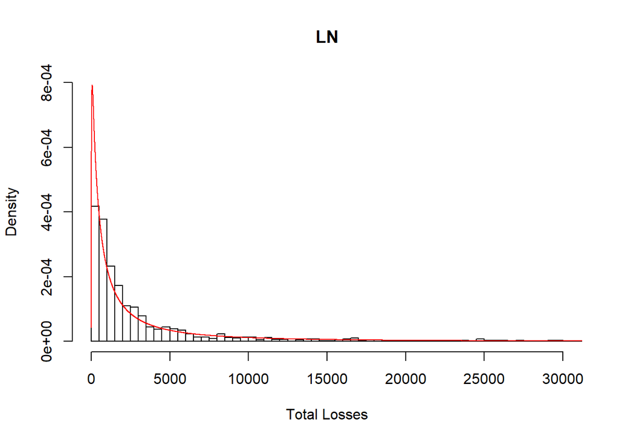

```r
hist(sev.dat$Loss,xlab="Total Losses",main="LN",breaks=100,freq=F,xlim=c(0,3e4),ylim=c(0,8e-4))
x <- seq(1,max(sev.dat$Loss),1)
mu <- zop.LN$par[1]
sigma <- zop.LN$par[2]
lines(x,dlnorm(x,mu,sigma),col="red")
```

#### 7.3.4.2 Pareto

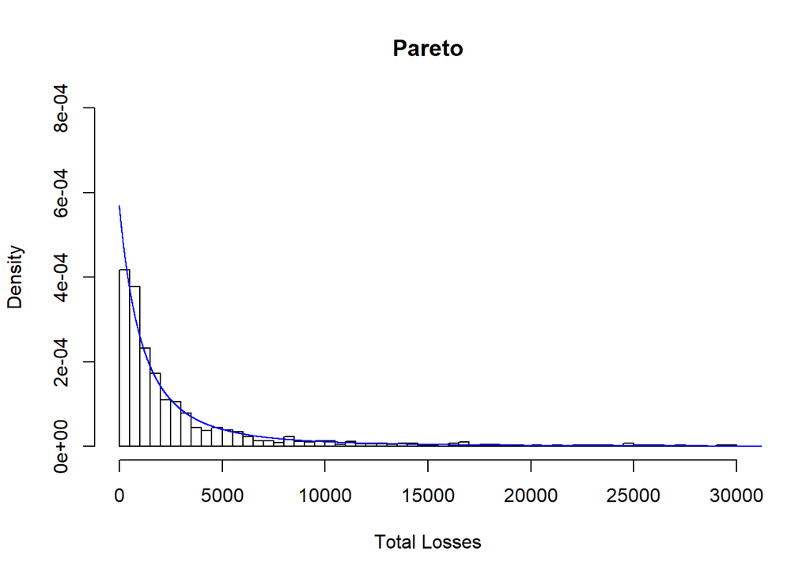

```r
hist(sev.dat$Loss,xlab="Total Losses",main="Pareto",breaks=100,freq=F,xlim=c(0,3e4),ylim=c(0,8e-4))
x <- seq(1,max(sev.dat$Loss),1)
theta <- zop.P$par[1]
alpha <- zop.P$par[2]
lines(x,dpareto(x,theta,alpha),col="blue")
```

### 7.3.5 qq Plots

#### 7.3.5.1 Define Quantile Function of Pareto

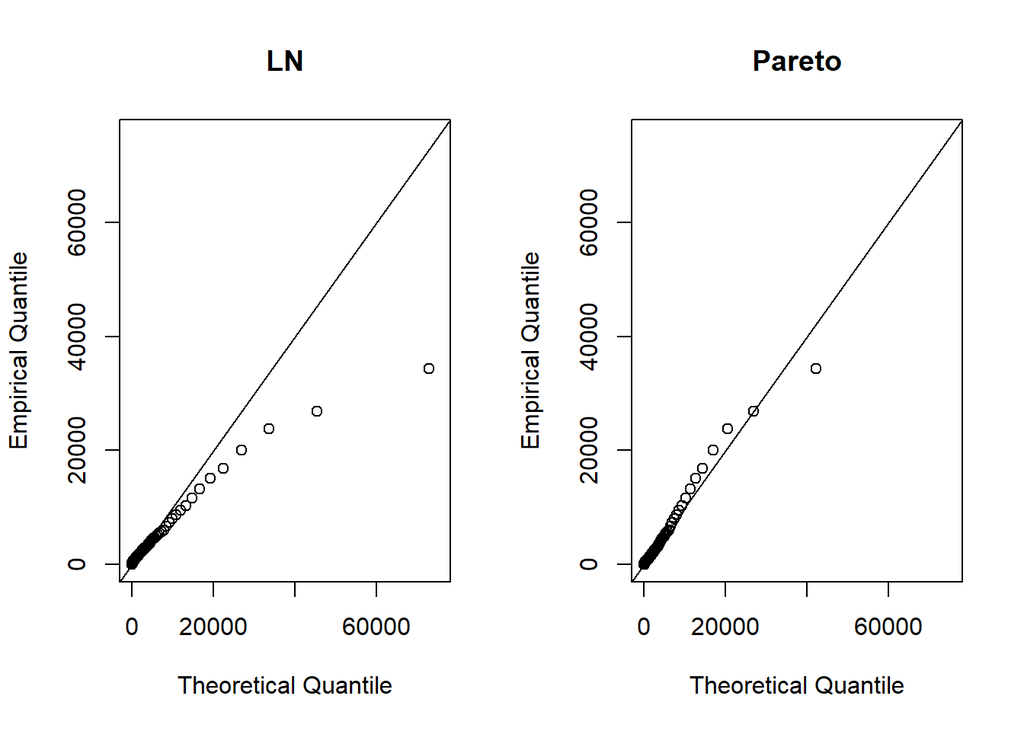

```r
qpareto <- function(p,theta,alpha){theta*((1-p)^(-1/alpha)-1)}
pct <- seq(0.01,0.99,0.01)
par(mfrow=c(1,2))
plot(qlnorm(pct,mu,sigma),quantile(sev.dat$Loss,probs=pct),
     main="LN", xlab="Theoretical Quantile", ylab="Empirical Quantile",
     xlim=c(0,7.5e4),ylim=c(0,7.5e4))
abline(0,1)
plot(qpareto(pct,theta,alpha),quantile(sev.dat$Loss,probs=pct),
     main="Pareto", xlab="Theoretical Quantile", ylab="Empirical Quantile",
     xlim=c(0,7.5e4),ylim=c(0,7.5e4))
abline(0,1)
```

# 8 Tweedie

*This file contains illustrative **R** code for the Tweedie distribution. When reviewing this code, you should open an **R** session, copy-and-paste the code, and see it perform. Then, you will be able to change parameters, look up commands, and so forth, as you go.*

## 8.1 Tweedie distribution

### 8.1.1 Load Tweedie Package

First bring in the package Tweedie (you may need to first install this package).

```r
library(tweedie)
```

### 8.1.2 Set Paramteres for Tweedie(p,mu,phi)

Setting parameters p, mu and phi defines the specific features of the distribution.

Furthermore, setting a specific seed allows us to generate the same randomn numbers so we can produce identical distributions

```r
set.seed(123)
p <- 1.5
mu <- exp(1)
phi <- exp(1)
```

### 8.1.3 Set Sample Size

Sample size is set to 500 for this example. “y” holds all 500 obserations from tweedie distribution with the given parameters.

```r
n <- 500
y <- rtweedie(n,p,mu,phi)
```

### 8.1.4 Show Summary Statistics

Here we calculate important statisitics like mean, median, standard deviation and quantiles.

```r
summary(y)
```

```
   Min. 1st Qu.  Median    Mean 3rd Qu.    Max.
  0.000   0.000   1.438   2.687   3.878  24.181
```

```r
sd(y)
```

```
[1] 3.346954
```

```r
quantile(y,seq(0,1,0.1))
```

```
        0%        10%        20%        30%        40%        50%
 0.0000000  0.0000000  0.0000000  0.0000000  0.7275496  1.4378933
       60%        70%        80%        90%       100%
 2.3767214  3.4212150  5.2317625  7.7471281 24.1813833
```

### 8.1.5 Show Histogram

Histograms are useful for visually interpreting data. Sometime summary statistics aren’t enough to see the full picture.

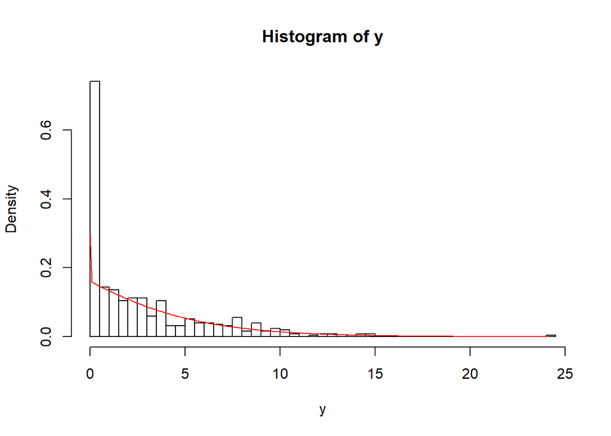

```r
hist(y, prob=T,breaks=50)
x <- seq(0,max(y),0.1)
lines(x,dtweedie(x,p,mu,phi),col="red")
```

### 8.1.6 QQ Plots for Different p Values

A QQ plot is a plot of the quantiles of the first data set against the quantiles of the second data set.

This is graphical technique for determining if two data sets come from populations with a common distribution.

It appears here that a power of 1.5 matches the distribution best.

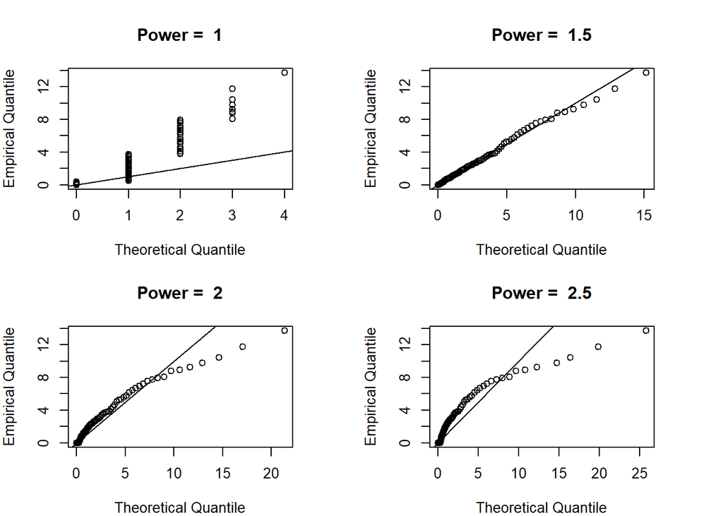

```r
par(mfrow=c(2,2),mar=c(4,4,4,4))
qqTweedie <- function(xi,pct,mu,phi) {
  plot(qtweedie(pct,xi,mu,phi),quantile(y,probs=pct),
       main=paste("Power = ",xi), xlab="Theoretical Quantile", ylab="Empirical Quantile")
  abline(0,1)
}
pct <- seq(0.01,0.99,0.01)
lapply(c(1,1.5,2,2.5),qqTweedie,pct=pct,mu=mu,phi=phi)
```

### 8.1.7 Fit Tweedie Distribution

Here we run a “glm” for the Tweedie distribution. you may need to first install the “statmod” package

```r
library(statmod)
fit <- glm(y~1,family=tweedie(var.power=1.5,link.power=0))
summary(fit)
```

```
Call:
glm(formula = y ~ 1, family = tweedie(var.power = 1.5, link.power = 0))

Deviance Residuals:
    Min       1Q   Median       3Q      Max
-2.5607  -2.5607  -0.6876   0.5155   5.1207

Coefficients:
            Estimate Std. Error t value Pr(>|t|)
(Intercept)   0.9885     0.0557   17.75   <2e-16 ***
---
Signif. codes:  0 '***' 0.001 '**' 0.01 '*' 0.05 '.' 0.1 ' ' 1

(Dispersion parameter for Tweedie family taken to be 2.542861)

    Null deviance: 1618.8  on 499  degrees of freedom
Residual deviance: 1618.8  on 499  degrees of freedom
AIC: NA

Number of Fisher Scoring iterations: 4
```

### 8.1.8 Show Parameter Estimates

We now display the parameter estimates calculated in the glm.

```r
summary(fit)$coefficient
```

```
             Estimate Std. Error  t value    Pr(>|t|)
(Intercept) 0.9885415  0.0556989 17.74795 5.42159e-55
```

```r
summary(fit)$dispersion
```

```
[1] 2.542861
```

### 8.1.9 Maximum Likelihood Estimation

Here we run a “MLE” to determine the most likely parameters of the Tweedie distribution.

```r
loglik<-function(parms){
  p=parms[1]
  mu=exp(parms[2])
  phi=exp(parms[3])
  llk <- -sum(log(dtweedie(y, p, mu, phi)))
  llk
}
ini <- c(1.5,1,1)
zop <- nlminb(ini,loglik, lower =c(1+1e-6,-Inf,-Inf),upper =c(2-1e-6,Inf,Inf))
print(zop)
```

```
$par
[1] 1.4823346 0.9885411 0.9871154

$objective
[1] 1122.992

$convergence
[1] 0

$iterations
[1] 14

$evaluations
function gradient
      23       77

$message
[1] "relative convergence (4)"
```

### 8.1.10 Obtain Standard Error

Now we calculate the standard errors of our parameter estimates from the MLE. You may need to first install the “numDeriv” package.

```r
library(numDeriv)
est <- zop$par
names(est) <- c("p","mu","phi")
hess<-hessian(loglik,est)
se <-sqrt(diag(solve(hess)))
print(cbind(est,se))
```

```
          est         se
p   1.4823346 0.02260226
mu  0.9885411 0.05672086
phi 0.9871154 0.05060983
```

# 9 Bootstrap Estimation

*This file demonstrates both empirical and parametric boostrap simulation. When reviewing this code, you should open an **R** session, copy-and-paste the code, and see it perform. Then, you will be able to change parameters, look up commands, and so forth, as you go.*

## 9.1 Empirical Bootstrap

Example: 90% confidence interval for the mean. Consider outcomes of rolling a fair die.

### 9.1.1 Random sample

Here we input a sample of 10 observations, which we are going to build our estimates off of.

```r
y <- c(1,3,2,5,4,5,5,6,6,6)
n <- length(y)
n
```

```
[1] 10
```

### 9.1.2 Sample mean

Finding the mean of the random sample.

```r
xbar <- mean(y)
xbar
```

```
[1] 4.3
```

### 9.1.3 Random resamples from y

#### 9.1.3.1 Set bootstrap sample size

We’re going to generate 30 different observations using the original sample data, called the *boostrap sample*

```r
nboot <- 30
tmpdata <- sample(y,n*nboot,replace=TRUE)
bootstrap.sample <- matrix(tmpdata,nrow=n,ncol=nboot)
```

#### 9.1.3.2 Compute sample mean for each bootstrap sample

Here we find the mean for all 30 of our boostrap samples.

```r
bsmeans <- colMeans(bootstrap.sample)
bsmeans
```

```
 [1] 3.8 4.8 4.5 4.4 4.4 4.3 4.5 4.5 5.2 4.6 3.5 4.1 4.6 4.3 4.5 4.9 4.6
[18] 4.0 4.8 4.0 4.5 4.0 4.8 4.3 4.2 4.6 3.3 3.4 4.4 3.6
```

### 9.1.4 90% confidence interval

Using the generated boostrap sample, we calculate a 90% confidence interval for our sample mean.

```r
CI <- c(quantile(bsmeans,prob=0.05), quantile(bsmeans,prob=0.95))
CI
```

```
   5%   95%
3.445 4.855
```

## 9.2 Parametric Bootstrap

Example: confidence interval for 1/theta. Consider y ~ exponential(theta=10).

### 9.2.1 random sample of size 250

This time we generate a random sample of 250 observations from the exponential sampling distribution.

```r
y <- rexp(250,rate=0.1)
n <- length(y)
n
```

```
[1] 250
```

### 9.2.2 The MLE for lambda: 1/xbar

Remember from earlier that the MLE of theta for an exponential distribution is its mean.

```r
theta.mle <- mean(y)
rate.hat <- 1/theta.mle
```

### 9.2.3 Generate bootstrap samples

Using the MLE we calculated we now generate 500 *bootstrap samples* of 250 observations each.

```r
nboot <- 500
tmpdata <- rexp(n*nboot,rate=rate.hat)
bootstrap.sample <- matrix(tmpdata,nrow=n,ncol=nboot)
```

### 9.2.4 compute botstrap statistics

We now find the rate parameter for each of our *boostrap samples*

```r
rate.star <- 1/colMeans(bootstrap.sample)
```

### 9.2.5 calculate deviation from sample statistics

Subtracting the original sample rate parameter from each of our simulated rate parameters, we can find the 5th and 95th percentiles of the differences.

```r
delta.star <- rate.star - rate.hat
delta.lb <- quantile(delta.star,prob=0.05)
delta.ub <- quantile(delta.star,prob=0.95)
```

### 9.2.6 90% confidence intervel

We use the percentiles to create a 90% CI for the rate parameter.

```r
CI <- rate.hat - c(delta.ub,delta.lb)
print(CI)
```

```
       95%         5%
0.08817793 0.10884260
```